# Towards a more accurate definition of death

By: Andrew McKenzie; Last Major Update: 2022-01-23; Status: Draft

- Link to the index: https://brainpreservation.github.io/

## Summary

Our society’s definition of death has shifted over time. It depends upon the available medical technology, such as CPR and artificial respiration. In the future, the definition of death will almost certainly be different than it is today.

One possible improved definition of death would be when the information in the person’s brain that they value is irreversibly lost, which is known as information-theoretic death or total death.

A more accurate definition of death also requires distinguishing living and dying as distinct processes. It is already possible for life to be briefly paused without causing information-theoretic death, for example as sometimes occurs with cardiac arrest.

Pausing life for an extended period without causing information-theoretic death could potentially be done with a long-term preservation procedure that is known to be reversible. This would be long-term suspended animation. No such technology exists today.

Pausing life without causing information-theoretic death could also potentially be done with a long-term preservation method that is *not* known to be reversible today, but which has the goal of preserving information in the brain so that it could *become* reversible in the future with improvements in technology. This is brain preservation.

In other words, when people are declared legally dead today, my claim is that it is *theoretically* possible that we can preserve the information in their brains in a static state so that, with future technology, they will be able to be revived. Whether such a brain preservation procedure is *actually* possible today is a question that can only be answered with certainty in the future.

This neuroscience-informed definition of life and death is the entire point of brain preservation. It is the major paradigm shift required to understand everything else in these essays.

## What is death?

On first learning about brain preservation, many will respond that it doesn’t make sense. They will say something like, “why would you preserve someone who is already dead?”

The answer is that it would be useless to preserve someone who is already dead. But when we declare people dead by today’s medicolegal standards, they are not necessarily dead by tomorrow’s more biologically accurate standards of death.

An important flip side of this is that even before we call someone dead by today’s medicolegal standards, they may already be dead by the standards of the future. Tomorrow’s standards of death will not always be more sanguine. Consider brain death: by the time some people are declared legally dead of brain death, they may have been dead from an information-theoretic death perspective for some time.

### A brief history of declaring death

When to call someone dead has caused problems for a long time [(Laureys, 2005)](https://www.nature.com/articles/nrn1789). In one common historical way to determine medicolegal death, physicians would “feel for the pulse, listen for breathing, hold a mirror before the nose to test for condensation, and look to see if the pupils were fixed” [(Sarbey, 2016)](https://www.ncbi.nlm.nih.gov/pmc/articles/PMC5570697/). From our current perspective, we can consider these to be cardiopulmonary standards of death. By cardiopulmonary standards, if someone lacks a pulse or respiration, they are declared dead.

With advances in medical technology, these traditional cardiopulmonary standards of death were complicated in many ways in the 20th century.

In the 1950s, people first began to experiment with restoring circulatory function following cardiac arrest by external stimulation of the chest. They reported that this could lead to survival. In 1960, it was shown in a landmark study that chest compressions after cardiac arrest led to a significant rate of survival [(Kouwenhoven et al., 1960)](https://pubmed.ncbi.nlm.nih.gov/14411374/). In this initial study of 20 patients, 70% were reported to survive cardiac arrest, in part due to the use of chest compressions.

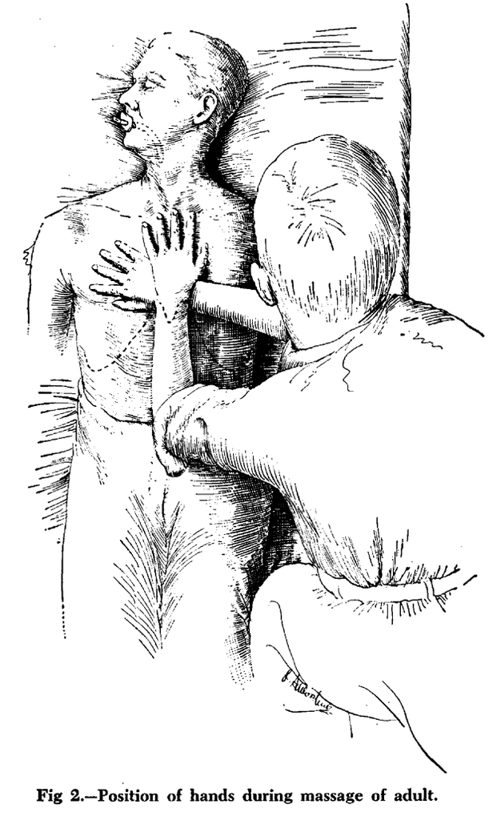

The invention of CPR; Source: [Kouwenhoven et al 1960](https://pubmed.ncbi.nlm.nih.gov/7860008/)

Over the next several decades, it began to become standard practice in many areas of the world, that if someone’s heartbeat stopped, clinicians would not simply declare them dead: instead, they would initiate a course of cardiopulmonary resuscitation (CPR) that might involve chest compressions, rescue breathing, defibrillation, and/or epinephrine injection. Only once the course of CPR was considered futile would death be declared [(Whetstine et al., 2005)](https://www.ncbi.nlm.nih.gov/pmc/articles/PMC1414041/). CPR is now the standard of care for those who desire it. In many jurisdictions, clinicians and others must undergo frequent training in its use.

In 1967, the first heart transplant was performed [(Truog et al., 2018)](https://pubmed.ncbi.nlm.nih.gov/29879281/). Once heart and lung transplants were in clinical use, there was another reason that someone couldn’t be declared dead if they lacked a pulse or weren’t breathing: because they might be in the process of receiving a heart or lung transplant [(Sarbey, 2016)](https://academic.oup.com/jlb/article/3/3/743/2327864). It would cause quite a headache for one’s lawyer if receiving a heart or lung transplant meant that one was declared legally dead during the middle of the procedure.

Things became even more complicated as a result of artificial respiration. In the 1950s, the new medical technology of positive pressure ventilators meant that we could extend the life of people who could not breathe on their own and otherwise would have died [(Truog et al., 2018)](https://pubmed.ncbi.nlm.nih.gov/29879281/). But some of these people were found to have no apparent cognitive function. This led to a tremendous emotional and financial burden with seemingly no purpose. It also prevented these people, who had effectively no hope of meaningful cognitive recovery with current technology, from donating their organs to others.

In 1968, in response to the problems resulting from artificial respiration, a committee at Harvard Medical School published a report describing a new definition of death based on neurologic criteria [(Truog et al., 2018)](https://pubmed.ncbi.nlm.nih.gov/29879281/). Their stated goal was to “define irreversible coma as a new criterion for death.” Their report led to a definition of brain death based on absence of responses to stimuli, the lack of spontaneous movement or breathing, and the absence of neurologic reflexes. This was among the first definitions of brain death.

In most states in the United States, there are currently two types of legal death: circulatory death and brain death. A model state law was written in 1981 called the Uniform Determination of Death Act (UDDA). The UDDA defines death as: “An individual who has sustained either 1) irreversible cessation of circulatory and respiratory functions, or 2) irreversible cessation of all functions of the entire brain, including the brain stem, is dead. A determination of death must be made with accepted medical standards.” [(Wijdicks et al., 2010)](https://pubmed.ncbi.nlm.nih.gov/20530327/).

Circulatory death is similar to the historic cardiopulmonary standards of death. It is how most people conceptualize death: your heart stops pumping, your lungs stop exchanging air, and blood stops flowing through your body. In many contexts, unless someone declares themselves to be in the Do Not Resuscitate (DNR) category, then circulatory death will only be declared after an attempt at cardiopulmonary resuscitation (CPR) is made and deemed to fail [(Gary Marklin et al., 2021)](https://www.uptodate.com/contents/evaluation-of-the-potential-deceased-organ-donor-adult)

Specific brain death criteria varies by state and even by hospital. For adults, a standard method for determining brain death was written by the American Academy of Neurology in 2010 and includes a series of criteria that must be fulfilled and tests that must be performed prior to the declaration of brain death [(Wijdicks et al., 2010)](https://pubmed.ncbi.nlm.nih.gov/20530327/). These criteria include the absence of brainstem reflexes as well as apnea when a person is disconnected from the ventilator.

The vagueness of the UDDA brain death criteria has proven quite controversial. For example, it implies that hormone function in the hypothalamus should not be present, even though hypothalamic function is often still present in people declared dead by brain death criteria [(Erik Greb, 2020)](https://www.the-hospitalist.org/hospitalist/article/214955/traumatic-brain-injury/experts-call-revise-uniform-determination-death).

[(Joffe et al., 2021)](https://peh-med.biomedcentral.com/articles/10.1186/s13010-021-00107-9) describe some of the problems with brain death criteria. They propose that one way forward is to “accept the higher brain death criterion of death of the person.” To describe this, they quote [(Baker et al., 2014)](https://pubmed.ncbi.nlm.nih.gov/24930370/), who write “being dead can be defined as: absent brain function with no biological potential in the brain to reinstate sufficient cell function required to achieve emergence to consciousness and self-awareness.”

I agree with this formulation of higher brain death: while it may be difficult for some to accept, the best way forward is to accept that the brain defines the fundamental aspects of what it means to be a human, and that when this is no longer recoverable, the person is dead. The higher brain death criterion will be the implicit definition of brain death I use in these essays.

As these examples show, our medicolegal definition of death [varies across eras and between locations](https://web.archive.org/web/20160507022945/https://www.geripal.org/2012/05/mostly-dead-vs-completely-dead.html). It depends on the available medical technology, our state of knowledge about biomedicine, and, ideally, the person’s preferences.

Many academics in the field argue that our current definitions of death are inconsistent and problematic [(Sarbey, 2016)](https://www.ncbi.nlm.nih.gov/pmc/articles/PMC5570697/). It is reasonable to expect that our current definition of death will be improved upon in the future.

### Summary of possible states in the dying process

[output not shown]

### Information-theoretic death

Instead of our society’s current definitions of death, we can imagine how a future society, in the possession of better medical knowledge and technology, would define death.

One possible definition of death is when the information in the brain is completely destroyed. In 1992, Merkle described information-theoretic death as the following [(Merkle, 1992)](https://pubmed.ncbi.nlm.nih.gov/1435395/):

> A person is dead according to the information theoretic criterion if their memories, personality, hopes, dreams, etc have been destroyed in the information theoretic sense. If the structures in the brain that encode memory and personality have been so disrupted that it is no longer possible in principle to recover them, then the person is dead. If they are sufficiently intact that inference of the state of memory and personality are feasible in principle, and therefore restoration to an appropriate functional state is likewise feasible in principle, then the person is *not dead*.

Similar definitions have been described by other authors. Doyle describes “absolutely irreversible death” as another term for “information-theoretic death” [(Doyle, 2018)](https://link.springer.com/chapter/10.1007/978-3-319-94950-5_5). They describe it as when “destruction of the brain has occurred to such an extreme that any information it may have ever held is irrevocably lost for all eternity. This, some people argue, is the only real (irreversible) form of death.”

Others have called a similar phenomenon “total death,” which is a term used as early as 1975 (as cited in [(Lafontaine, 2009)](https://www.tandfonline.com/doi/full/10.1080/09505430903123008)). Choosing among these terms comes down to semantics. In these essays, I will use information-theoretic death because it is more commonly used in cryonics.

A commonly used analogy to explain information-theoretic death is to imagine the text on pages of a print book. If the book is torn into its individual pages and strewn about a building, it cannot be easily read and in that sense it cannot function. But the textual information is still present somewhere in the building, so theoretically the pages could be put back together and the book read once again. Whereas if a book is burned to dust, the information has been lost, and this information loss is irreversible given our current understanding of physics [(Whetstine et al., 2005)](https://www.ncbi.nlm.nih.gov/pmc/articles/PMC1414041/).

To more precisely distinguish between information-theoretic death and current medicolegal death, these essays will use the following definitions of clinical death and legal death:

> *Clinical death*: The cessation of blood circulation and breathing.

> *Legal death*: Declared dead by current medicolegal standards in a given jurisdiction. If a person’s heart stops beating or their brain function is irreversibly lost, and there is a failure of resuscitation or a reason to not attempt resuscitation, then they are declared legally dead by most current medicolegal standards.

It’s important to note that people frequently experience clinical death without experiencing legal death. For example, in certain anesthesia procedures, such as hypothermic cardiac arrest, clinical death is induced, with the goal of reversing it after the surgical operation [(Mauduit et al., 2021)](https://www.ncbi.nlm.nih.gov/pmc/articles/PMC8526149/).

It’s also true that medical professionals sometimes declare legal death and then the person comes back to life. This is known as the Lazarus phenomenon. One review article summarizes 38 published cases of return of spontaneous circulation (ROSC) after cessation of CPR [(Adhiyaman et al., 2007)](https://www.ncbi.nlm.nih.gov/pmc/articles/PMC2121643). This can lead to significant medicolegal consequences for the treating physicians. Because most cases of spontaneous ROSC occur within 10 minutes of cessation of CPR, the article recommends for physicians to wait at least 10 minutes after the cessation of CPR prior to declaring legal death.

There’s an old debate within cryonics over how one should refer to conserved bodies. [Some people](https://www.alcor.org/library/death-of-death/) think that calling people who have been preserved “dead” is problematic and causes people to dismiss the idea. Others think that the term “dead” is more straightforward, and refusing to call people who have been preserved “dead” [is confusing](http://forum.oregoncryo.com/viewtopic.php?f=2&t=33) and makes cryonics seem like a cult.

Both sides have good points. Regarding this controversy, I personally try to use the terms “legally dead” or “legal death” when discussing people whose brains have been conserved with the goal of eventual revival. It’s straightforward and also has the connotation of not necessarily agreeing fully with the current medicolegal definition of death.

However, I also sometimes just use the terms “dead” or “death,” with the understanding that it doesn’t necessarily mean “information-theoretic death.” For this reason, I also don’t mind it when people refer to conserved bodies as cadavers or corpses. I think it’s accurate and straightforward to describe conserved people as dead. While it might be better if conserved people had a more protected legal status, that is not the world we live in today.

To continue the analogy of the torn book, if someone is legally dead, then the pages of their book have been torn. But this does not mean that they cannot be put back together in the future, given medical technology advancements. So, the dying process is only final once the information that defines them is irreversibly lost. While they are clinically and legally dead, preserved people may not yet be totally dead – that determination will be up to clinicians and scientists of the future. The challenge for now is how to get them to the future where such technology may have been invented.

## Is it possible to pause life without causing information-theoretic death?

All of the above discussion is highly academic unless it is possible to “pause life” without causing information-theoretic death. Life is sometimes defined as the opposite of death. But in order to be able to pause life without causing death, then we need to have a working definition of life that is not just the opposite of death.

In these essays, human life will be defined as requiring certain spontaneous patterns of electrochemical activity in the brain. This may seem arbitrary and others may define human life differently, but this definition is consistent with the definition of brain death and our knowledge of neuroscience.

Information-theoretic death will be defined as when the structures that mediate the neural activity that a person values – what defines their memories, personality, and other aspects of their identity that they value – have completely decomposed and are no longer inferable.

Pausing life, then, requires the absence of electrochemical neural activity without the decomposition of structural information in the brain. As Wowk [puts it](https://alcor.org/Library/html/medicaltimetravel.htm), “Death is not when life turns off. Death is when the chemistry of life becomes irreversibly damaged.” Pausing life – at least in theory – allows for the theoretic possibility of medical time travel; sort of like taking an ambulance to the future.

### Pausing electrical activity

Ben Franklin, in addition to [recognizing the complexity of life and death](https://www.reddit.com/r/cryonics/comments/j4fls4/benjamin_franklins_1773_letter_to_jacques/), was one of the pioneers of the study of electricity. Among other contributions, he proposed a [famous experiment](https://en.wikipedia.org/wiki/Benjamin_Franklin#Electricity) using a kite to gather electric charge from a storm cloud, showing that lightning was composed of electricity.

So we can only imagine his surprise if he had learned in his lifetime that the brain also operates via electricity. Ions like sodium, potassium, calcium, and chloride flow in and out of brain cells through channel proteins on cell membranes. Ions flow as a result of intricate equilibria and in response to external and internal stimuli. These ion movements often occur in bursts of electrochemical discharges called action potentials. Summed together, this electrochemical activity allows rapid communication between brain cells.

The scope and speed of electrochemical activity in the brain, relative to human spatiotemporal scales, is sometimes underappreciated. Action potentials are driven in part by chemical signaling at synapses and by local diffusion of neuromodulators. There are also gap junctions, ephaptic coupling, and other forms of signaling that contribute to electrical communication [(Faber et al., 2018)](https://www.ncbi.nlm.nih.gov/pmc/articles/PMC6276723). In the human brain, [there are thought to be](https://biology.stackexchange.com/questions/30104/what-are-the-total-number-of-action-potentials-in-the-human-brain) billions or even trillions of action potentials per second. And electrical activity is clearly not based solely on action potentials, as sub-threshold electrical activity that does not reach the level of an action potential also contains information. It all sums up to a symphony of electrochemical activity that allows you to think and read these words.

The maintenance of electrochemical activity in the brain is exquisitely sensitive to blood flow. A lack of blood flow to the brain leads to a lack of electrical activity within about 40 seconds [(Dreier et al., 2018)](https://www.ncbi.nlm.nih.gov/pmc/articles/PMC5901399/). This rapid electrical inhibition has been called an “austerity program” because it is thought to be an active process by which neurons recognize that their energy stores have been depleted and attempt to conserve them, in case energy can be restored. Within a few more minutes without blood flow, the austerity programs break down and there are waves of electrical activity, called spreading depolarizations, that can be detected within the brain. After spreading depolarizations occur, there is generally no more spontaneous electrical activity in the brain in the absence of intervention. After this point, the brain is called electrically silent.

The neural structures that shape electrical activity in the brain take a bit longer to degrade, on a time scale of minutes to hours, but they too begin to degrade quickly. One study found that structural changes to dendrites, which are membrane extensions of neurons, can begin to occur within three minutes of lack of blood flow [(Murphy et al., 2008)](http://www.jneurosci.org/content/28/7/1756). However, as we will discuss later, some neural structures can take hours or even days to degrade.

A schematic developed by [(Madea, 1994)](https://pubmed.ncbi.nlm.nih.gov/7860008/) that could be applied to any organ describes what happens in the absence of blood flow to the brain: there is a rapid loss of function – in the case of the brain, coordinated electrochemical activity – followed by a slower loss of structural information.

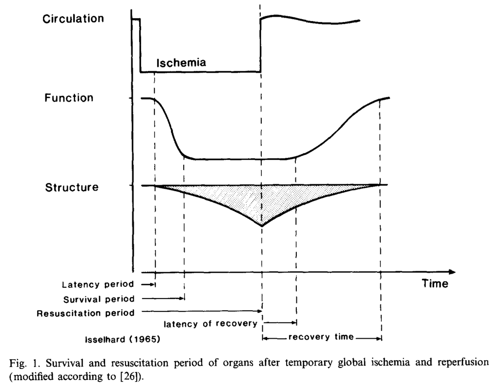

The principle of supravitality; [Madea 1994](https://pubmed.ncbi.nlm.nih.gov/7860008/)

The general idea of Madea’s is that after cessation of blood flow, function is lost first, then structure. Based on this principle alone, it is likely that there is a time window in which dynamic functions such as long-term memory recall no longer occur in the brain but the structural information that underlies them is still present.

Damage due to the post-mortem interval can theoretically be minimized by the use of immediate preservation procedures within the time window where memories have been retained following cardiac arrest and cardiopulmonary resuscitation. In controlled experiments in mammals at room temperature, this time window has been shown to vary from approximately 10 to 30 minutes [(de Wolf et al., 2020)](https://www.liebertpub.com/doi/10.1089/rej.2019.2225) [(Allen et al., 2012)](https://academic.oup.com/ejcts/article/41/5/1132/385553).

### Is it possible to pause neural activity while retaining long-term cognitive functions?

Some people have an intuitive sense that continuous subjective experience is necessary for maintaining one’s memories and personality. “Wherever you go, there you are,” as the saying goes. One’s continuous subjective experience may be slightly interrupted by the universal experience of sleep and the common experience of anesthesia. But sleep and most forms of anesthesia don’t pause electrical activity in the brain. They just suppress it. So people are sometimes skeptical of the idea that it is even possible to pause electrical activity while retaining long-term memories and personality. However, there is convincing data in humans that this is possible.

The first set of data comes from a surgical procedure called deep hypothermic circulatory arrest [(Arrowsmith et al., 2009)](https://jhu.pure.elsevier.com/en/publications/deep-hypothermic-circulatory-arrest-3). It is performed in surgeries where blood flow to the brain must be momentarily halted, such as repairing the aortic arch or operating on giant aneurysms in the blood vessels of the brain. It involves cooling the body’s core temperature to 20-25xC and then halting blood flow to the brain. When deep hypothermic circulatory arrest procedure is performed, electrical activity in the brain, as measured by an EEG, stops for up to an hour. Many people who undergo it appear to have minimal changes in their cognitive functions including long-term memory, even those with high cognitive demand occupations such as musicians and artists [(Ziganshin et al., 2013)](https://www.ncbi.nlm.nih.gov/pmc/articles/PMC3741856/).

The second set of data comes from people who have experienced cardiac arrest as a result of hypothermia. For example, one study analyzed cases from people who had suffered cardiac arrest as a result of being buried by an avalanche while skiing [(Boué et al., 2014)](https://pubmed.ncbi.nlm.nih.gov/24971508/). Although it was a rare outcome, two of the patients who were able to be resuscitated after 6 or 7 hours of burial under snow had good cognitive performance and were able to return to work, suggesting retained long-term memory and personality function. Such cases capture our imagination and are an inspiration for the aphorism that no one is dead until they are warm and dead.

These cases show the importance of low temperatures for surviving lack of blood flow to the brain with cognitive functions intact, which will be discussed in later essays. But for now, the major point of emphasis is that long periods without blood flow to the brain, during which we expect that all coordinated electrical activity in the brain will be silenced, is not sufficient to destroy long-term memories and personality. Therefore, while long-term memories clearly require dynamic electrical activity to be recalled, what needs to be preserved in the brain to retain them are the structures that produce the dynamical system, not the exact dynamic state [(Sandberg, 2013)](https://link.springer.com/chapter/10.1007/978-3-642-31674-6_19).

Animal studies corroborate and extend this human data. For example, rats taught to solve a task have been reported to have no significant loss of memory after resuscitation from body temperatures only slightly above 0xC (as cited in [(Smith, 1959)](https://www.ncbi.nlm.nih.gov/pubmed/13831887)). This is despite complete loss of spontaneous electrical activity in the cortex for up to 2 hours (as cited in [(Smith, 1959)](https://www.ncbi.nlm.nih.gov/pubmed/13831887)).

One important counterpoint here is that cognitive functions that last over the relatively short-term, such as the information in working memory, do seem to rely on the maintenance of dynamic electrochemical activity. As a result, it is expected that these short-term dynamic functions would likely be lost during a brain preservation procedure. This is why we focus on long-term cognitive functions, which fortunately is also what humans tend to value. Considering the circumstances that might lead up to a preservation procedure, [as Hires points out](https://brainslab.wordpress.com/2020/09/11/archiving-the-hayworth-miller-2019-debate-about-brain-preservation/), this is generally considered a feature, not a bug. The division between short-term and long-term cognitive functions is unclear and it is an area of uncertainty, but the situation is more clear at the extremes.

### Is it possible to pause biological time while retaining long-term memories?

Time is a more confusing concept than it often gets credit for, although pointing this out won’t win you any friends if you show up late for a meeting. There are many different types of time. In physics, there is linear time – as measured by a universal clock – and spacetime – in which time is related to motion in space, and in which time can be “dilated” by movement. In programming, there is wall time – what you see on the clock – and CPU time – how much time is spent actually running a program. In medicine, time is often used to refer to the age of an organism, for example chronological aging – based on a person’s date of birth – or biological aging – a theoretical measure that can be approximated based on biomarkers such as what state cellular epigenetic clocks are in [(Maestrini et al., 2018)](https://www.frontiersin.org/articles/10.3389/fcell.2018.00055/full).

In cryobiology, the notion of biological time quantifies the amount of biologically meaningful molecular motion there is within a system. Molecular motion can be thought of as a molecule’s geometric exploration. It can take the form of translation, rotation, or vibration. However, molecular bond vibrations are thought to be much less consequential since they occur within a fixed molecular structure [(Wowk, 2010)](https://www.ncbi.nlm.nih.gov/pubmed/19538955). Most of the biologically meaningful molecular motion is in the form of translational and rotation, which allow molecules to meet, react, and do all the things that make up life. Thus, biological time can be defined as the occurrence of translational or rotational molecular motions within a biological system (G. M. Fahy et al., 1984); [(Tucker et al., 2007)](https://books.google.com/books?hl=en&lr=&id=qEvARNDEX9sC&oi=fnd&pg=PA1&ots=vae2usCvjH&sig=blJBfZT0gTRjGTWIcj_luXSar-k#v=onepage&q&f=false). According to this definition of biological time, if the molecules in a biological system do not translate or rotate, then time does not flow with respect to that system.

The surgical procedure of deep hypothermic cardiac arrest and cases of accidental hypothermia with cardiac arrest show that memories do not require continuous electrical activity in the brain. Pausing biological time goes further than that. One might imagine that some sort of continuous molecular motion might be required for the maintenance of memory. Here, there is no human data because no human has been preserved with a process that pauses biological time and later revived; however, there is some non-human data that we can draw upon.

For the past half-century, the small roundworm *C. elegans* has been a frequently used model organism in neuroscience. Like humans, their nervous systems do not solely rely on electrical communication at synapses but also employ a complex set of neuropeptides and other molecular signaling pathways.

In one experiment, investigators first taught a set of worms (*C. elegans*) where an odor that they like (benzaldehyde) was present on a dish [(Vita-More et al., 2015)](https://www.ncbi.nlm.nih.gov/pmc/articles/PMC4620520/). The worms tended to migrate towards the odor. They then vitrified the worms by cryopreservation, and stored them at liquid nitrogen (-196x C) temperature for 30 minutes. At such a low temperature, biological time is effectively paused. When they rewarmed the worms, they showed that the worms retained the same migration preference that they had learned. This experiment shows biological time can be paused while organisms can still retain long-term memories.

Another data point about the effect of pausing biological time on neural information comes from experiments in brain slices. A common model of memory storage is called long-term potentiation, which is often studied in brain slices from the hippocampus. In this method, synapses are electrically stimulated at high-frequency. After this high-frequency stimulation, subsequent stimulation at the same synapses causes a larger post-synaptic electrical response. Although memory itself can not be studied in brain slices, this model of memory can be.

In one study, investigators reported that they took thin slices from the hippocampus of rabbits, vitrified them by cryopreservation, and found that they retained the same long-term potentiation responses as control slices that were not vitrified [(Gregory M. Fahy et al., 2013)](https://www.tandfonline.com/doi/full/10.3109/00498254.2012.728300). It’s important to point out that, to the best of my knowledge, this study has not been replicated, which adds uncertainty to any conclusions based on it. However, to the extent that we can trust it, it suggests that while full mammalian brains cannot yet be reversibly vitrified, a key model of memory can be preserved in mammalian nervous systems by a procedure that pauses biological time.

### Summary of pausing life while retaining cognitive information

What these data have shown is that it is possible to stop electrochemical neuronal activity (in humans) and biological time (in other animals) without loss of memories. These are existence proofs for the possibility of a brain preservation procedure that could preserve memories without requiring continuous electrochemical activity or molecular motion.

On the basis of this data, it is still possible to make an argument that important types of human cognitive functions might survive pausing electrical activity but not biological time. But it would require postulating a model in which the human nervous system works much differently than what is seen in *C. elegans* and differently than what is seen in mammalian brain slices. It seems quite unlikely.

We can say that almost certainly, the cognitive functions that most people care about are encoded by static structures. Importantly, what these data do *not* show is that any particular brain preservation procedure will necessarily preserve the static morphologic and biomolecular structures that make up the information for valued cognitive functions. That needs to be evaluated as a separate consideration.

## Brain preservation is not suspended animation

It’s important to be explicit about what suspended animation is and how brain preservation is different; otherwise, people tend to end up in interminable debates about terminology and goals.

Suspended animation is the slowing or stopping of physiology in a way that is known to be reversible. In other words, it can be thought of as a method of preservation for which the revival method has already been achieved.

Suspended animation is possible today over the short-term. For example, in deep hypothermic cardiac arrest, it has been shown that animals whose brains are cooled sufficiently can survive cessation of blood flow for one hour and resuscitation without brain damage [(O’Connor et al., 1986)](https://pubmed.ncbi.nlm.nih.gov/3954495/).

There is no currently known method for achieving *long-term* suspended animation in humans. Establishing the precise distribution of chemical preservatives that seems to be required across an organ the size of the human brain, let alone the whole body, appears to be a very hard problem. To me, achieving long-term human suspended animation seems likely to be decades away at a minimum. Some others think a long-term suspended animation method could be developed sooner. I hope they are right. But long-term suspended animation is not the focus of these essays.

Brain preservation is the slowing or stopping of physiology in a way that is *not* yet known to be reversible. While a given brain preservation method might one day be discovered to be reversible with future technology, it also might not. There is a high amount of uncertainty about the outcome, even in an ideal case where the medicolegal circumstances for brain preservation work out as well as they could.

There are some procedures for brain preservation today that might *eventually* be iterated upon and lead to a method for suspended animation. But in that case, what we would then call the procedure would be different; it would be called suspended animation, not brain preservation.

The difference between brain preservation and suspended animation causes considerable debates within cryonics among people with different goals. For example, some people will say that as soon as someone is able to be preserved and revived, then finally more people will become interested in cryonics. My response to this argument is two-fold:

1. Obviously. 2. That’s no longer brain preservation. That’s long-term suspended animation. Brain preservation is by definition preservation of the structures wherein you *don’t* know whether you can ever bring the person back.

One of the reasons that this is a crucial distinction is that different preservation methods may be differentially more likely to achieve the goals of long-term suspended animation as opposed to brain preservation. The pure cryopreservation method using cryoprotectants alone is much more plausibly on the path towards long-term suspended animation, but that doesn’t mean that it’s the best method for structural brain preservation available today.

Supposedly knowledgeable people have been saying that long-term suspended animation is right around the corner since the 1960s. Many people at the time – both cryonicists and critics of cryonics – were overly optimistic about how soon true long-term suspended animation could be achieved. Robert Ettinger thought that long-term suspended animation would be achieved quickly. The physician Dante Brunol also thought it was “only a few years,” although he did not get the funding or support that Ettinger assured him that he would [(Perry, 2015)](https://www.alcor.org/docs/cryonics-magazine-2015-05.pdf). As an example of a critic of cryonics who thought that long-term suspended animation was imminent, see Robert Prehoda’s 1969 book *Suspended animation: The research possibility that may allow man to conquer the limiting chains of time* [(Prehoda, 1969)](https://books.google.com/books/about/Suspended_Animation.html?id=SEhDAAAAIAAJ). Suffice it to say that long-term suspended animation hasn’t happened. Brain preservation is the best we have, and in my view likely will have, for many decades.

Another reason this is a crucial distinction relates to the framing of the procedure. One can ask whether brain preservation will exist even if long-term suspended animation is possible. Even in that hypothetical world, there might still be challenging medical circumstances where the brain has already undergone significant damage, so that the available long-term suspended animation techniques are not possible. For example, the blood vessels might no longer be accessible. There might be a question of whether or not that person should have their brain preserved if they desired to be preserved with the goal of eventual revival.

For example, let’s say that someone’s brain is sectioned by a medical examiner performing an involuntary autopsy. In addition to the cutting damage, during this time the brain is at room temperature and decomposing to a significant degree. And let’s say that the person desired preservation even under adverse circumstances.

Let’s imagine that we are members of the brain preservation team. Once we have access to that person’s brain, should we preserve it and hope that enough information is still present for eventual revival? Some people think it’s simply the right thing to preserve the brain regardless, that we are doing our best in the face of uncertainty. Arguably, this is the ethically conservative decision and it relates to the framing of the procedure as brain *conservation*. It is also consistent with one of the higher ideals of medicine, which is that people should not be turned away from care if they desire it, no matter how sick they are.

On the other hand, preserving the sectioned pieces of an already highly decomposed brain is about as far from conventional medicine as one can imagine. So this framing of the procedure is in contradistinction to the understandable but potentially confusing attempts to frame current brain preservation procedures as the type of long-term suspended animation that one might imagine being done as an extension of emergency medicine [(Eveleth, 2014)](https://www.theatlantic.com/technology/archive/2014/08/for-200000-this-lab-will-swap-your-bodys-blood-for-antifreeze/379074/).

To be clear, I don’t want to come across as negative about long-term suspended animation research. I fully support long-term suspended animation research, in the same way I fully support anti-aging research. There is a sense in which brain preservation wants to be long-term suspended animation. There are also many obvious synergies. People focused on long-term suspended animation are focusing on the whole journey, whereas people interested in brain preservation are focusing on the first part of the journey. It’s just that, as with anti-aging research, I doubt that long-term suspended animation research is going to help people in the near future to avoid information-theoretic death, so I’m not as interested in it.

### We will not know whether revival following brain preservation procedures performed today is possible until the future

We most definitely do not currently have the ability to revive people preserved for the long-term with currently available brain preservation methods. But that doesn’t mean that such a revival technology could never be invented. We can imagine two important milestones:

1. *Preservation milestone*: The invention of a technology that retains information in the brain in a potentially revivable form for a long time. For example, as described in [this Metaculus question](https://www.metaculus.com/questions/3382/what-will-the-earliest-preservation-date-of-any-resuscitated-cryonics-patient-be/).

2. *Revival milestone*: The invention of a technology that could revive an organism preserved by at least one long-term preservation method. For example, as described in [this Metaculus question](https://www.metaculus.com/questions/3331/first-revivaluploading-of-cryonics-patient/).

Clearly, we have not achieved the revival milestone for any contemporary long-term preservation method. If the revival milestone is ever reached, it will almost certainly be far in the future.

Whether the preservation milestone has been achieved, on the other hand, is an unknown. This is why claims that “brain preservation doesn’t work” ring hollow. We don’t know whether or not it works yet. We may already be there with an existing brain preservation procedure. We may have been there in the 1960s. People’s probability estimates on how likely it is that we have achieved the preservation milestone can differ dramatically. When the revival milestones occur for different preservation procedures could also vary significantly; it depends on how future society and future technology develop.

There will almost certainly be a substantial gap between the preservation and revival milestones, which will only be able to be established in the future with the benefit of hindsight.

Because the preservation milestone is likely to be achieved many decades or even centuries prior to the revival milestone, most people will legally die without knowing whether it has been achieved. Many critics of brain preservation will legally die thinking it was not possible. Many proponents will legally die thinking it was possible.

## Long-term memories

In these essays, we will focus on long-term memories as one of the most important types of information in a person’s brain. Long-term memories are both easier to preserve than short-term memories and generally much more valued.

Memories, while quite abstract, are much more concrete than the ever elusive concept of personal identity, in other words, what “makes a person who they are” [(Olson, 2021)](https://plato.stanford.edu/entries/identity-personal/). For example, one could imagine quantifying the percentage of memories of a certain type that are recalled after a preservation procedure. You could also imagine quantifying the probability of recalling a particular memory that was present prior to the preservation, such as a password that you had memorized.

At this point, many people correctly point out that one’s set of memories is constantly changing. As people go through life, they acquire new memories and forget old ones. And there is also evidence that every time people recall a memory, it can be altered. Our feelings about them also change.

And it’s not just memories that change. Identity, personality, and preferences are also constantly changing. Someone might enjoy bird watching at age 30 but find it boring by age 60, or vice versa [(Hogg, 1996)](https://www.alcor.org/cryonics/cryonics1996-3.pdf#page=20).

It’s really no surprise that these emergent properties of the brain so frequently change, given that the structure of one’s brain changes constantly. There are often news articles that say that some experience or intervention changes your brain – unsurprising since literally everything changes your brain. It doesn’t even make sense to say “doing absolutely nothing changes your brain,” because from the perspective of your brain, there is no such thing as doing absolutely nothing.

Some people will say that if memories are constantly changing, then one’s set of memories is arbitrary and not of any particular meaning. There are some worldviews that emphasize this impermanence as a reason to disregard one’s eventual death. However, many people do find that while some memories come and go – or even change – there are others that last nearly a lifetime. There is something constant in these memories that they and their loved ones value.

It is likewise with personality. Some people feel that there is no point of preserving oneself with brain preservation because one’s personality is constantly changing. Clearly, there are questions here about the meaning of existence that brain preservation is not able to answer.

There is a concept in the philosophy literature known as “ordinary survival” that is a useful way of thinking about this topic. This concept was developed by the philosopher Derek Parfit [(Parfit, 2016)](https://onlinelibrary.wiley.com/doi/10.1002/9781118922590.ch8) and explained in the book *Frozen to Life* by DJ MacLennan [(MacLennan, 2015)](https://books.google.com/books/about/Frozen_to_Life.html?id=yOolswEACAAJ).

Ordinary survival recognizes that one’s repertoire of long-term memories and one’s personality style are not constants and are instead constantly changing. For example, one type of ordinary survival is the type of survival that occurs when one loses consciousness by sleep and regains consciousness upon awakening. In some sense, the changes in one’s memory and personality is a type of death. And yet, there are stable aspects of personal identity that last over days and years.

When I speak of retention of memories by a brain preservation method, I speak of retention in the sense of ordinary survival: the type of retention of memories that would occur after sleep, anesthesia, or some other ordinary event – not necessarily perfect, but accepted as good enough by nearly everyone. In the same way most people don’t fret about whether they will be the same person in the morning when going to sleep at night, revival following a successful brain preservation procedure would meet the criteria of ordinary survival.

It’s also worth pointing out that some information in one’s brain may be lost in brain preservation procedure. For example, one could imagine that information about one’s circadian rhythm – such as sleep/wake regulation – could be stored in a more labile way than long-term memories. Circadian rhythms might be dependent on the precise distribution of biomolecules within cells in the hypothalamus that might not be accurately inferable following a brain preservation procedure. In this case, one could imagine that one’s individual circadian rhythm might be replaced by a species-generic version. For some people, this type of change to the circadian rhythm might be really problematic. Others might view it as a win.

There is a need to be precise and pragmatic about what a brain preservation procedure is likely to be able to accomplish. For this reason, I will focus largely on long-term memories.

### Personal choice in defining information-theoretic death

Many have argued that people should have a degree of choice in how exactly death is defined for them [(Ross, 2018)](https://onlinelibrary.wiley.com/doi/full/10.1002/hast.956). Within the information-theoretic death framework, we could allow people to decide what brain functions are valued to them, and in turn, we could allow people to (prospectively!) choose what type of cognitive function information loss they would consider to be death.

At the extremes, there are some obvious considerations. If someone is conscious, then it seems that they are clearly alive and not dead [(Ross, 2018)](https://onlinelibrary.wiley.com/doi/full/10.1002/hast.956). Theoretically, as a result of a change to one’s brain, someone might feel that at some point in the past, they branched into a new person and that a former version of them is dead, but from the perspective of ordinary survival, this possibility can be discounted.

On the other hand, if someone’s brain has fully liquified, which almost always eventually happens after cardiac arrest at room temperature, then we can say that information-theoretic death has occurred. Reviving them at this point would require external information of functional neural recordings made prior to their death – almost certainly beyond the capabilities of our current technology. Or the ability to meaningfully reverse random diffusion-based physics to infer the state of the brain prior to total liquefaction, which, based on my understanding of physics, is impossible.

Within these extremes, it seems there is a gray zone of possible information-theoretic death that depends on the cognitive functions that the individual values. For many people, it is certain higher-order brain functions, such as memories and aspects of their personality, that they most value. If all of these valued cognitive functions were lost, then they might say that information-theoretic death had occurred.

Practically speaking, it may be difficult to allow people this choice given our current knowledge and technology. But it seems an important long-term goal to let people define information-theoretic death on their own terms. So while I have focused on long-term memories, others may have different goals and those should be respected as well.

## Conclusion

Although medicolegal criteria suggest otherwise, in actuality, death is not an event, rather it is a process or a continuum. From the perspective of memory preservation, personality preservation, or more generally information preservation, death can begin years prior to one’s actual legal death. It tends to accelerate dramatically in the weeks, days, hours, and minutes leading up to the legal declaration of death. Following the legal declaration of death, the dying process continues rapidly, until at some unknown time point, information-theoretic death is reached.

In the Kuhnian sense, the current paradigm for the medicolegal definition of death serves pretty well. But seriously considering the idea of brain preservation requires a paradigm shift in the way people think about life/living and death/dying. My impression is that our inability to effectively communicate the redefinition of death is a major barrier to people becoming interested in the field.

Quite separate from the question of whether it is *theoretically* possible to stop neural activity and biological time while retaining long-term memory information, which I think is highly likely, is the question of whether it is *currently* possible to preserve the valued information in someone’s brain given our brain preservation methods, our available resources, and our medicolegal environments. This is much more uncertain and will be the focus of most of the rest of these essays.

## Related FAQ

The fact that electrical silence occurs rapidly in the absence of blood flow to the brain answers a common question about brain preservation procedures:

> q: Are people whose brains have been preserved conscious during storage?

In practice, this is not possible. Any currently conceivable long-term brain preservation method will prevent electrical activity in the brain, which is a bare minimum requirement for consciousness.

The idea that brain preservation is about attempting to pause life also helps to answer another commonly asked question about brain preservation:

> q: Who wants to live forever?

Brain preservation doesn’t necessarily offer that and choosing to pursue brain preservation does *not* mean that you want to live forever. It’s just a last-ditch attempt to avoid dying. There’s a big difference.

Many people want to avoid dying because they love their family and friends and want to spend more time with them, because there is much more they want to see and do in the universe, and/or because they are curious about what will happen in the future. None of these things are about living forever.

> q: Because brain preservation avoids the “natural” course of events, does that mean it is bad or wrong?

It is the same as any kind of medicine. Of course, this is not “natural” in the same way that all medicine is not natural, since the eras of Esagil-kin-apli, Hippocrates, and al-Razi. Medicine is all about intervening in the “natural” course of events. In fact, one might say that it is “natural” for humans to want to intervene in disease and death. What could be more human than trying to defeat death?

Some people do not like this about medicine in general, in which case they will likely feel the same way about brain preservation. Others do not think that medical interventions in the natural course of events is problematic, as long as the patient is informed of the possible risks and benefits and desires the treatment. For these people, there is little reason to single out brain preservation as a particularly problematic endeavor.

> q: Does brain preservation need to be shown to work in a randomized control trial before it can be offered?

Some people claim that in conventional medicine, treatments are only approved following a randomized control trial.

However, this is clearly not true. For example, the landmark paper introducing chest compressions after cardiac arrest and suggesting its use in the 1960s did not present any randomized evidence [(Kouwenhoven et al., 1960)](https://pubmed.ncbi.nlm.nih.gov/14411374/). Instead, there was an implicit comparison to doing nothing and a reasonable biophysical case made that this procedure would lead to improved perfusion of the brain.

Because there is no alternative to brain preservation at the time of one’s legal death if someone wants to avoid information-theoretic death, there is no equipoise.

Also, almost by definition, brain preservation cannot be shown to work – on the metric that we care about, which is revival – in a trial before it is offered. It would either have to be a trial of long-term suspended animation, which does not exist, or the timescale of the trial would have to be so long that by the time it was adjudicated the preservation technology tested would almost certainly no longer be the best available.

If not suspended animation, what standards should brain preservation meet? This is an open question. It seems critical to be able to ask *some* sort of proxy question about “how likely is it to have worked?” This could be based on structural preservation metrics for each case. It also seems critical to tell the patient’s family members or advocates and the world at large about the quality of the preservation. Otherwise, all sorts of problems develop because of the lack of feedback. This will be discussed in later essays.

While there is no indication for randomized trial evidence comparing brain preservation to no brain preservation, there is a good case for randomized evidence comparing different brain preservation methods to another. If the field ever gets significant funding, this seems like a useful research project.

### Link to the next essay

https://brainpreservation.github.io/Embodied_Brain

### Link to return to the index

https://brainpreservation.github.io/

## References

Adhiyaman, V., Adhiyaman, S. and Sundaram, R., The Lazarus Phenomenon, *Journal of the Royal Society of Medicine*, vol. **100**, no. 12, pp. 552–57, December 2007.

Allen, B. S. and Buckberg, G. D., Studies of Isolated Global Brain Ischaemia: I. Overview of Irreversible Brain Injury and Evolution of a New Concept - Redefining the Time of Brain Death, *European Journal of Cardio-Thoracic Surgery: Official Journal of the European Association for Cardio-Thoracic Surgery*, vol. **41**, no. 5, pp. 1132–37, May 2012. DOI: 10.1093/ejcts/ezr315

Arrowsmith, J. and Hogue, C. W., Deep hypothermic circulatory arrest, *Cardiopulmonary Bypass*, pp. 125–39, January 2009. DOI: 10.1017/CBO9780511635564.011

Baker, A. and Shemie, S. D., Biophilosophical Basis for Identifying the Death of a Person, *Journal of Critical Care*, vol. **29**, no. 4, pp. 687–89, August 2014. DOI: 10.1016/j.jcrc.2014.04.013

Boué, Y., Payen, J.-F., Brun, J., Thomas, S., Levrat, A., Blancher, M., Debaty, G. and Bouzat, P., Survival After Avalanche-Induced Cardiac Arrest, *Resuscitation*, vol. **85**, no. 9, pp. 1192–96, September 2014. DOI: 10.1016/j.resuscitation.2014.06.015

de Wolf, A., Phaedra, C., Perry, R. M. and Maire, M., Ultrastructural Characterization of Prolonged Normothermic and Cold Cerebral Ischemia in the Adult Rat, *Rejuvenation Research*, vol. **23**, no. 3, pp. 193–206, June 2020. DOI: 10.1089/rej.2019.2225

Doyle, D. J., Life, Death, and Brain Death, in *What Does It Mean to Be Human? Life, Death, Personhood and the Transhumanist Movement*, D. J. Doyle, Ed., Cham: Springer International Publishing, pp. 93–112, 2018.

Dreier, J. P., Major, S., Foreman, B., Winkler, M. K. L., Kang, E.-J., Milakara, D., Lemale, C. L., et al., Terminal Spreading Depolarization and Electrical Silence in Death of Human Cerebral Cortex, *Annals of Neurology*, vol. **83**, no. 2, pp. 295–310, February 2018. DOI: 10.1002/ana.25147

Erik Greb, Experts Call to Revise the Uniform Determination of Death Act, *The Hospitalist*, January 2020.

Eveleth, R., For $200,000, This Cryonics Lab Will Replace Your Blood with Antifreeze, *The Atlantic*, August 2014.

Faber, D. S. and Pereda, A. E., Two Forms of Electrical Transmission Between Neurons, *Frontiers in Molecular Neuroscience*, vol. **11**, p. 427, November 2018. DOI: 10.3389/fnmol.2018.00427

Fahy, G. M., MacFarlane, D. R., Angell, C. A. and Meryman, H. T., Vitrification as an Approach to Cryopreservation, *Cryobiology*, vol. **21**, no. 4, pp. 407–26, August 1984. DOI: 10.1016/0011-2240(84)90079-8

Fahy, Gregory M., Guan, N., de Graaf, I. A. M., Tan, Y., Griffin, L. and Groothuis, G. M. M., Cryopreservation of Precision-Cut Tissue Slices, *Xenobiotica*, vol. **43**, no. 1, pp. 113–32, January 2013. DOI: 10.3109/00498254.2012.728300

Gary Marklin, and Ron Shapiro, Evaluation of the Potential Deceased Organ Donor (Adult), 2021.

Hogg, T., Information Storage and Computational Aspects of Repair, *Cryonics Magazine*, vol. **17**, no. 3, 1996.

Joffe, A. R., Khaira, G. and de Caen, A. R., The Intractable Problems with Brain Death and Possible Solutions, *Philosophy, Ethics, and Humanities in Medicine*, vol. **16**, no. 1, p. 11, October 2021. DOI: 10.1186/s13010-021-00107-9

Kouwenhoven, W. B., Jude, J. R. and Knickerbocker, G. G., Closed-Chest Cardiac Massage, *JAMA*, vol. **173**, pp. 1064–67, July 1960. DOI: 10.1001/jama.1960.03020280004002

Lafontaine, C., The Postmortal Condition: From the Biomedical Deconstruction of Death to the Extension of Longevity, *Science as Culture*, vol. **18**, no. 3, pp. 297–312, September 2009. DOI: 10.1080/09505430903123008

Laureys, S., Science and Society: Death, Unconsciousness and the Brain, *Nature Reviews. Neuroscience*, vol. **6**, no. 11, pp. 899–909, November 2005. DOI: 10.1038/nrn1789

MacLennan, D. J., *Frozen to Life: A Personal Mortality Experiment*, Anatta Books, 2015.

Madea, B., Importance of Supravitality in Forensic Medicine, *Forensic Science International*, vol. **69**, no. 3, pp. 221–41, December 1994. DOI: 10.1016/0379-0738(94)90386-7

Maestrini, D., Abler, D., Adhikarla, V., Armenian, S., Branciamore, S., Carlesso, N., Kuo, Y.-H., Marcucci, G., Sahoo, P. and Rockne, R. C., Aging in a Relativistic Biological Space-Time, *Frontiers in Cell and Developmental Biology*, vol. **6**, p. 55, 2018. DOI: 10.3389/fcell.2018.00055

Mauduit, M., Anselmi, A., Tomasi, J., Belhaj Soulami, R., Le Bars, F., Flecher, E. and Verhoye, J.-P., Does Hypothermic Circulatory Arrest for Aortic Surgery Trigger Near-Death Experience? Incidence of Near-Death Experiences After Aortic Surgeries Performed Under Hypothermic Circulatory Arrest, *AORTA Journal*, vol. **9**, no. 2, pp. 76–82, October 2021. DOI: 10.1055/s-0041-1725091

Merkle, R. C., The Technical Feasibility of Cryonics, *Medical Hypotheses*, vol. **39**, no. 1, pp. 6–16, September 1992. DOI: 10.1016/0306-9877(92)90133-w

Murphy, T. H., Li, P., Betts, K. and Liu, R., Two-Photon Imaging of Stroke Onset In Vivo Reveals That NMDA-Receptor Independent Ischemic Depolarization Is the Major Cause of Rapid Reversible Damage to Dendrites and Spines, *Journal of Neuroscience*, vol. **28**, no. 7, pp. 1756–72, February 2008. DOI: 10.1523/JNEUROSCI.5128-07.2008

O’Connor, J. V., Wilding, T., Farmer, P., Sher, J., Ergin, M. A. and Griepp, R. B., The Protective Effect of Profound Hypothermia on the Canine Central Nervous System During One Hour of Circulatory Arrest, *The Annals of Thoracic Surgery*, vol. **41**, no. 3, pp. 255–59, March 1986. DOI: 10.1016/s0003-4975(10)62765-8

Olson, E. T., Personal Identity, in *The Stanford Encyclopedia of Philosophy*, E. N. Zalta, Ed., Metaphysics Research Lab, Stanford University, 2021.

Parfit, D., Divided Minds and the Nature of Persons, in *Science Fiction and Philosophy*, John Wiley & Sons, Ltd, pp. 91–98, 2016.

Perry, R. M., What Did Brunol Say? Notes from the Architect of the First Controlled Human Cryonics Preservations, *Cryonics Magazine*, vol. **36**, no. 5, 2015.

Prehoda, R. W., *Suspended Animation: The Research Possibility That May Allow Man to Conquer the Limiting Chains of Time*, Chilton Book Company, 1969.

Ross, L. F., Respecting Choice in Definitions of Death, *Hastings Center Report*, vol. **48**, no. S4, pp. S53–55, 2018. DOI: 10.1002/hast.956

Sandberg, A., Feasibility of Whole Brain Emulation, in *Philosophy and Theory of Artificial Intelligence*, V. C. Müller, Ed., Berlin, Heidelberg: Springer, pp. 251–64, 2013.

Sarbey, B., Definitions of Death: Brain Death and What Matters in a Person, *Journal of Law and the Biosciences*, vol. **3**, no. 3, pp. 743–52, November 2016. DOI: 10.1093/jlb/lsw054

Smith, A. U., Viability of Supercooled and Frozen Mammals, *Annals of the New York Academy of Sciences*, vol. **80**, pp. 291–300, September 1959. DOI: 10.1111/j.1749-6632.1959.tb49209.x

Truog, R. D., Pope, T. M. and Jones, D. S., The 50-Year Legacy of the Harvard Report on Brain Death, *JAMA*, vol. **320**, no. 4, pp. 335–36, July 2018. DOI: 10.1001/jama.2018.6990

Tucker, M. and Liebermann, J., *Vitrification in Assisted Reproduction: A User’s Manual and Trouble-shooting Guide*, Pages 8-9: CRC Press, 2007.

Vita-More, N. and Barranco, D., Persistence of Long-Term Memory in Vitrified and Revived Caenorhabditis Elegans, *Rejuvenation Research*, vol. **18**, no. 5, pp. 458–63, October 2015. DOI: 10.1089/rej.2014.1636

Whetstine, L., Streat, S., Darwin, M. and Crippen, D., Pro/Con Ethics Debate: When Is Dead Really Dead?, *Critical Care*, vol. **9**, no. 6, pp. 538–42, 2005. DOI: 10.1186/cc3894

Wijdicks, E. F. M., Varelas, P. N., Gronseth, G. S., Greer, D. M. and American Academy of Neurology, Evidence-Based Guideline Update: Determining Brain Death in Adults: Report of the Quality Standards Subcommittee of the American Academy of Neurology, *Neurology*, vol. **74**, no. 23, pp. 1911–18, June 2010. DOI: 10.1212/WNL.0b013e3181e242a8

Wowk, B., Thermodynamic Aspects of Vitrification, *Cryobiology*, vol. **60**, no. 1, pp. 11–22, February 2010. DOI: 10.1016/j.cryobiol.2009.05.007

Ziganshin, B. A. and Elefteriades, J. A., Deep Hypothermic Circulatory Arrest, *Annals of Cardiothoracic Surgery*, vol. **2**, no. 3, pp. 303–15, May 2013. DOI: 10.3978/j.issn.2225-319X.2013.01.05